# 北京PM2.5数据分析

匡亚明学院 统计学 马宇恒 171240510

2020/5/28

报告为20年春季学期南京大学数学系时间序列分析课程作业。数据集来源于UCI机器学习数据库，贡献者为Liang, X., Zou, T., Guo, B., Li, S., Zhang, H., Zhang, S., Huang, H. and Chen, S. X.。本文分如下几个部分进行。后三个部分中包含了所要求的模型判别、参数估计、模型诊断的步骤。

- 数据预处理与探索
- 直接处理
- STL模型
- 回归

在文章最后，总结了本文得出的各种结论以及对政府的一些建议。

```r
library(VIM)
library(ggplot2)
library(mice)
library(Hmisc)
library(tseries)
library(forecast)
library(fUnitRoots)
library(patchwork)
set.seed(123)
```

### 数据预处理与探索

```r
data<-read.csv("PRSA_data_2010.1.1-2014.12.31.csv")
```

从数据库来源处我们可以查看各列的含义。

Attribute Information:

- No: row number
- year: year of data in this row
- month: month of data in this row
- day: day of data in this row
- hour: hour of data in this row
- pm2.5: PM2.5 concentration (ug/m^3)
- DEWP: Dew Point (ƒ)
- TEMP: Temperature (ƒ)
- PRES: Pressure (hPa)
- cbwd: Combined wind direction
- Iws: Cumulated wind speed (m/s)
- Is: Cumulated hours of snow
- Ir: Cumulated hours of rain

对各个时间维度上的数据进行可视化。

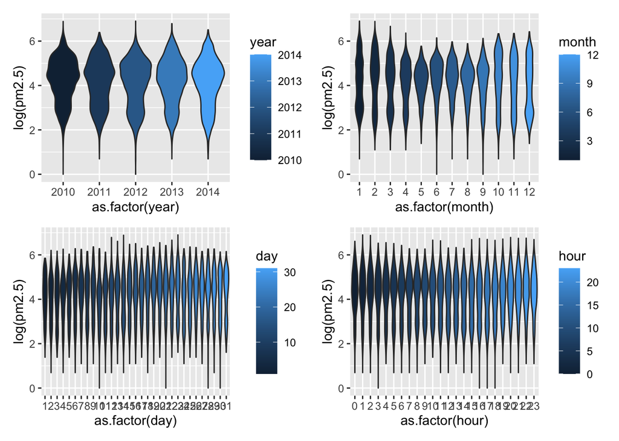

```r
# 总体趋势
# 取log以优化显示
ggplot(data,aes(x=as.factor(year),y=log(pm2.5)))+geom_violin(aes(fill=year))+ggplot(data,aes(x=as.factor(month),y=log(pm2.5)))+geom_violin(aes(fill=month))+ggplot(data,aes(x=as.factor(day),y=log(pm2.5)))+geom_violin(aes(fill=day))+ggplot(data,aes(x=as.factor(hour),y=log(pm2.5)))+geom_violin(aes(fill=hour))
```

我们来查看缺失值。

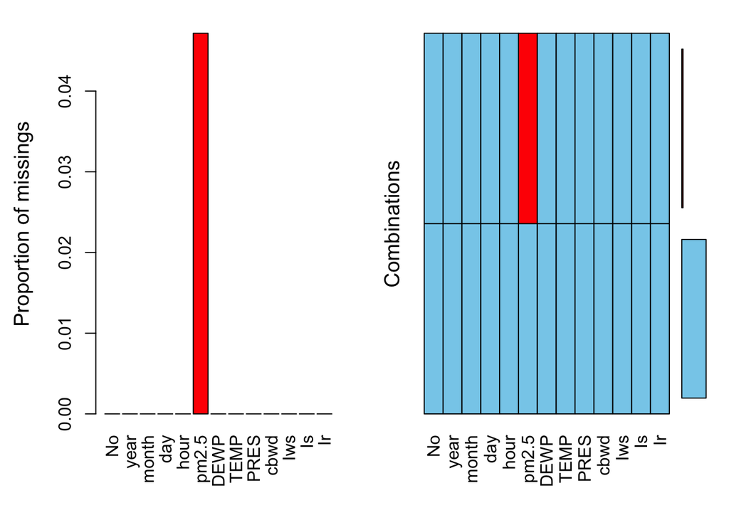

```r
aggr(data,prop=TRUE)
```

```r
na<-is.na(data$pm2.5)
# 计算连续缺失值序列占缺失值比例
sum(abs(c(na,0)-c(0,na)))/2/sum(na)
```

```
## [1] 0.1035317
```

只有PM2.5的测量值有缺失，那么我们需要对缺失值进行处理。由于本数据集很显然的含有周期信息，直接删除会丢失许多信息。由于数据量较大、持续时间相对缺失值较长，我们选择基于统计学的填充方法比如均值填充。而在此之前，我们对数据进行各种方式的拆分。

```r
# 调用数据的函数
getdata<-function(by,data,naomit=1){
  #按顺序取每年的平均值
  if(by=="year"){
    year<-unique(data$year)
    pm2.5<-NULL
    for (i in year){
       pm2.5<-c(pm2.5,mean(na.omit(data$pm2.5[data$year==i])))
    }
    result<-data.frame(year,pm2.5)
  }
  #按顺序取每月的平均值
  if(by=="month"){
    year<-NULL
    month<-NULL
    pm2.5<-NULL
    for (i in unique(data$year)){
      for (j in unique(data$month)){
          year<-c(year,i)
          month<-c(month,j)
          pm2.5<-c(pm2.5,mean(na.omit(data$pm2.5[as.logical(c(data$year==i)*c(data$month==j))])))
      }
    }
        result<-data.frame(year,month,pm2.5)
  }
  #按顺序取每天的平均值
  if (by=="day"){
    year<-NULL
    month<-NULL
    day<-NULL
    pm2.5<-NULL
    for (i in unique(data$year)){
      for (j in unique(data$month)){
        for (k in unique(data$day)){
          if (sum(c(data$year==i)*c(data$month==j)*c(data$day==k))==0){break}
          year<-c(year,i)
          month<-c(month,j)
          day<-c(day,k)
          pm2.5<-c(pm2.5,mean(na.omit(data$pm2.5[as.logical(c(data$year==i)*c(data$month==j)*c(data$day==k))])))
        }
      }
    }
        result<-data.frame(year,month,day,pm2.5)
  }
  result$no<-seq(nrow(result))
  return(result)
}
```

```r
datayear<-getdata("year",data)
datamonth<-getdata("month",data)
dataday<-getdata("day",data)
meanyear<-NULL
meanmonth<-NULL
meanday<-NULL
# 按照不同时间跨度分类
for (i in unique(data$year)){
  meanyear<-c(meanyear,mean(na.omit(data$pm2.5[data$year==i])))
}
for (i in unique(data$month)){
  meanmonth<-c(meanmonth,mean(na.omit(data$pm2.5[data$month==i])))
}
for (i in unique(data$day)){
  meanday<-c(meanday,mean(na.omit(data$pm2.5[data$day==i])))
}

dataday[1:30,]
```

```
##    year month day     pm2.5 no
## 1  2010     1   1       NaN  1
## 2  2010     1   2 145.95833  2
## 3  2010     1   3  78.83333  3
## 4  2010     1   4  31.33333  4
## 5  2010     1   5  42.45833  5
## 6  2010     1   6  56.41667  6
## 7  2010     1   7  69.00000  7
## 8  2010     1   8 176.20833  8
## 9  2010     1   9  88.50000  9
## 10 2010     1  10  57.25000 10
## 11 2010     1  11  20.00000 11
## 12 2010     1  12  20.75000 12
## 13 2010     1  13  40.20833 13
## 14 2010     1  14  93.70833 14
```

[output cut: 16 more lines]

```r
filleddataday<-impute(dataday$pm2.5,mean)
```

经过上述几种数据的整理方式，我们可以观察到缺失数据大多发生在不相连的一两天内。考察我们的时间序列是否为平稳序列。

```r
unitrootTest(filleddataday)
```

```
##
## Title:
##  Augmented Dickey-Fuller Test
##
## Test Results:
##   PARAMETER:
##     Lag Order: 1
##   STATISTIC:
##     DF: -12.1907
##   P VALUE:
##     t: < 2.2e-16
##     n: 0.01509
##
## Description:
##  Mon Jun  1 20:10:58 2020 by user:
```

```r
adf.test(filleddataday)
```

```
##
##  Augmented Dickey-Fuller Test
##
## data:  filleddataday
## Dickey-Fuller = -10.082, Lag order = 12, p-value = 0.01
## alternative hypothesis: stationary
```

但有这样的结果不一定因为其本身平稳，可能是数据量过大的缘故。故我们选择2010年的数据来考察。

```r
unitrootTest(filleddataday[1:365])
```

```
##
## Title:
##  Augmented Dickey-Fuller Test
##
## Test Results:
##   PARAMETER:
##     Lag Order: 1
##   STATISTIC:
##     DF: -5.2623
##   P VALUE:
##     t: 2.796e-07
##     n: 0.1135
##
## Description:
##  Mon Jun  1 20:10:58 2020 by user:
```

```r
adf.test(filleddataday[1:365])
```

```
##
##  Augmented Dickey-Fuller Test
##
## data:  filleddataday[1:365]
## Dickey-Fuller = -7.0439, Lag order = 7, p-value = 0.01
## alternative hypothesis: stationary
```

的确，我们可以把它当作平稳序列处理。

### 直接处理

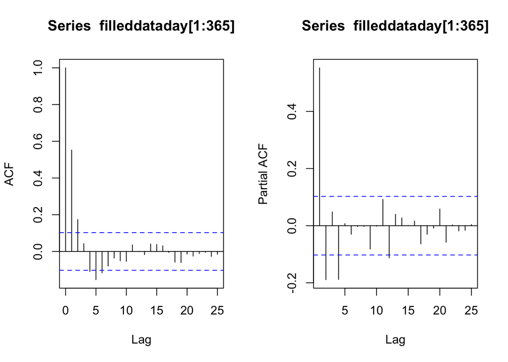

```r
par(mfrow=c(1,2))
acf(filleddataday[1:365])
pacf(filleddataday[1:365])
```

从模型中我们看到ACF在6阶后不显著为0，PACF在4阶后不显著为0。这里原本想要使用eacf来确认，但TSA包在5月初变成无法下载了，在重装了RStudio后便无法使用。为了防止过拟合，我们手动计算AIC值

```r
## 这里原本想要使用eacf来确认，但TSA包在5月初变成无法下载了，在重装了RStudio后便无法使用。为了防止过拟合，我们手动计算AIC值。
min=10000
for (i in 1:7) {
  for (j in 1:7){
    tmodel<-arima(filleddataday[1:365],order = c(i,0,j),transform.pars = TRUE,method = "ML")
    if (min>tmodel$aic){
    min=tmodel$aic
    print(min)
    print(c(i,j))
    }
  }
}
```

```
## [1] 4035.347
## [1] 1 1
## [1] 4033.337
## [1] 1 5
## [1] 4032.162
## [1] 4 1
## [1] 4030.031
## [1] 4 3
## [1] 4027.681
## [1] 4 4
## [1] 4027.469
## [1] 7 2
```

可以看到ARIMA(4,0,4)的AIC值为最小（(7,0,2)被故意舍去因为并没有提升很多AIC且阶数不合理），因此我们采用这个模型。

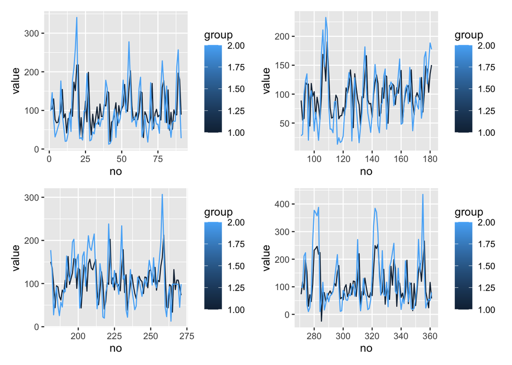

```r
tmodel<-arima(filleddataday[1:365],order = c(4,0,4))
forecast <- forecast(tmodel, h = 1, level = c(99.5))
plotdata<-data.frame(c(forecast$fitted,forecast$x),c(seq(365),seq(365)),c(rep(1,365),rep(2,365)))
colnames(plotdata)<-c("value","no","group")
plot_lst <- list()
b=90
for (i in 1:4){
  index<-c(1,91,181,271)
  a<-index[i]
plot_lst[[i]]<-ggplot(plotdata[c(a:(a+b),(365+a):(a+b+365)),],aes(x=no,y=value,group=group,colour=group))+geom_line()
  }
plot_lst[[1]]+ plot_lst[[2]]+plot_lst[[3]]+plot_lst[[4]]
```

可以看到，拟合的效果相当不错，但是总的来说预测的序列波动性比原序列小很多，这就提示我们在数据集的气象信息中可能有我们能够利用的东西。这个提示我们稍后处理，现在先来考察残差项。

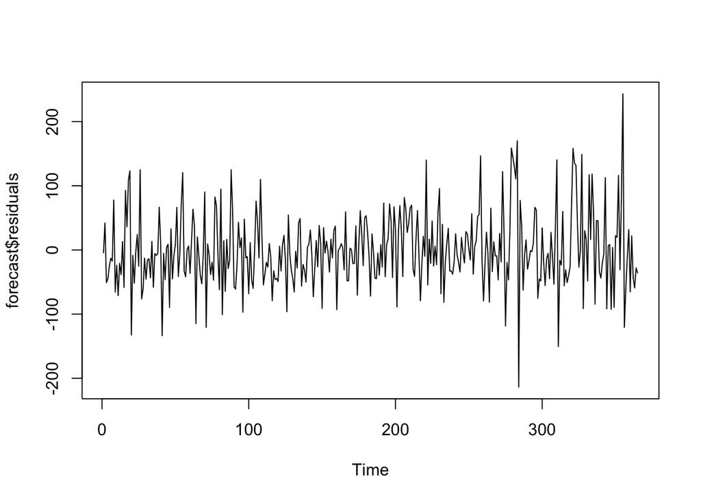

```r
plot(forecast$residuals)
```

肉眼观察来看，残差图具有一定的正态性。

```r
Box.test(forecast$residuals,type="Ljung-Box")
```

```
##
##  Box-Ljung test
##
## data:  forecast$residuals
## X-squared = 0.0060265, df = 1, p-value = 0.9381
```

的确，这个p值真的相当完美。

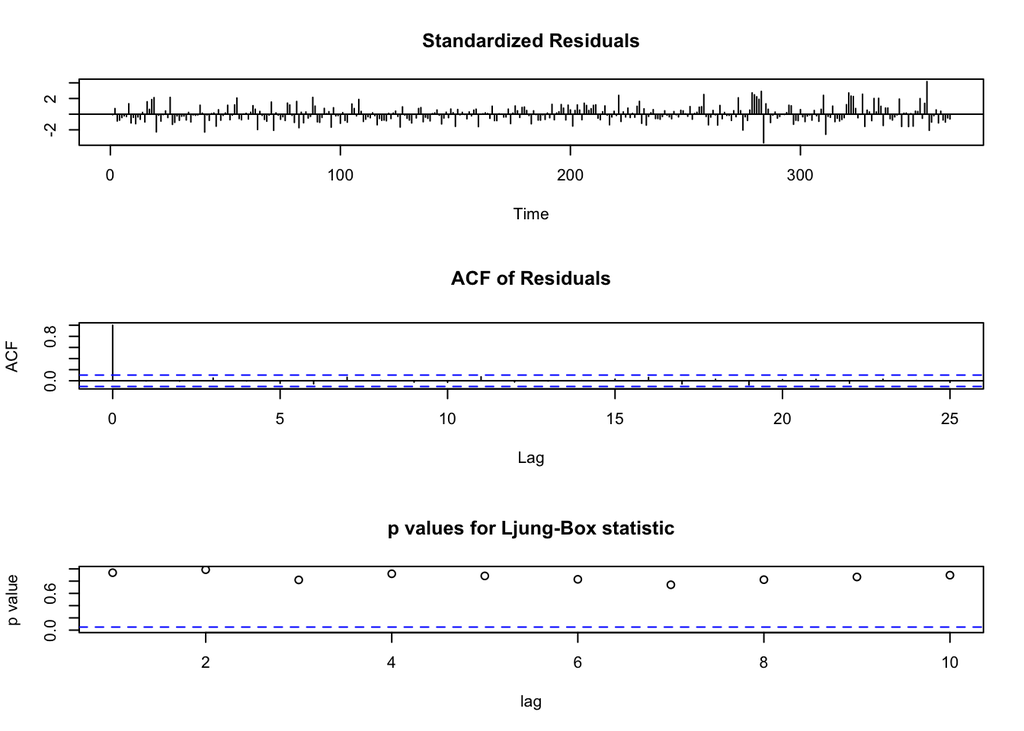

```r
tsdiag(tmodel)
```

残差序列完全没有自相关性，结果很好。接下来我们考虑不同年度数据之间的区别。一方面，气象条件对pm2.5对影响是巨大的。事实上，风力能够很大程度上决定pm2.5的含量。所以pm2.5数据应该以气候变化周期，即一年，有周期规律。同时，每年冬季的供暖也非常影响空气质量。但是同时，2010-2014五年间，我国对pm2.5的重视程度快速上升，颁布了很多关键性政策。所以不同年度之间的数据可能存在区别。让我们逐步分析。

### STL模型

首先来看2011年的数据。

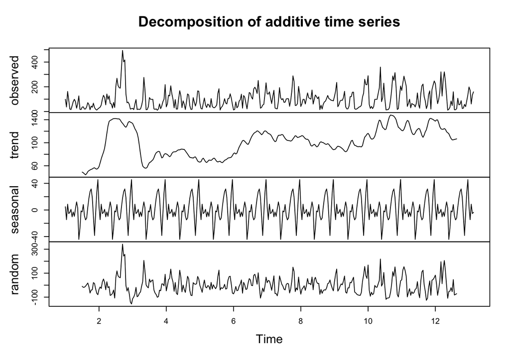

```r
tsfilleddataday<-ts(filleddataday[366:730],frequency = 30)
de<-decompose(tsfilleddataday,type = "add")
plot(de)
```

可以看到分解出了每个月的周期数据和趋势项。我们来看看一个周期内的数据。

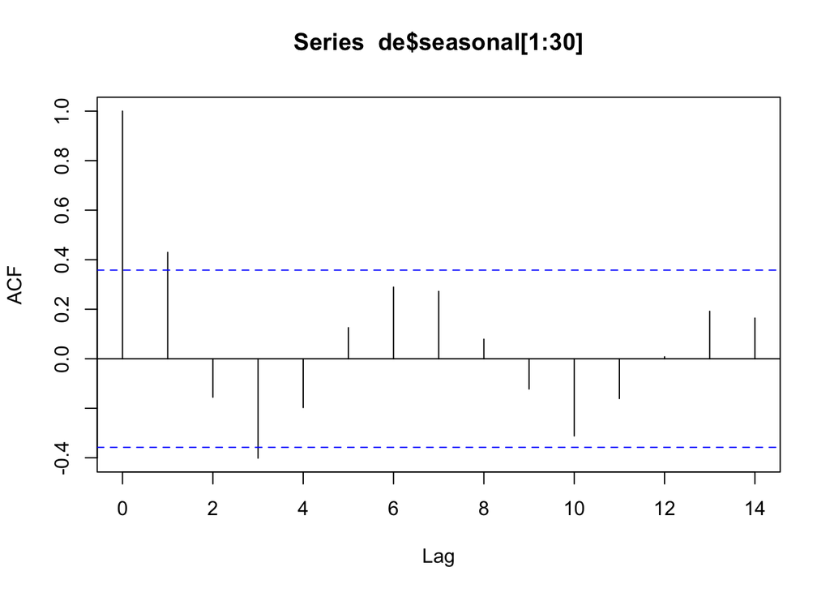

```r
acf(de$seasonal[1:30])
```

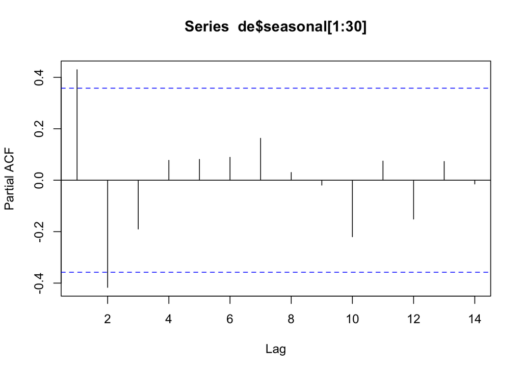

```r
pacf(de$seasonal[1:30])
```

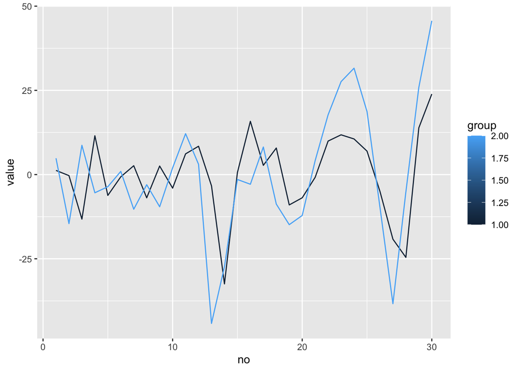

```r
monthmodel<-arima(de$seasonal[1:30],order = c(2,0,1))
monthforecast<-forecast(monthmodel, h = 1, level = c(99.5))
plotdata<-data.frame(c(monthforecast$fitted,monthforecast$x),c(seq(30),seq(30)),c(rep(1,30),rep(2,30)))
colnames(plotdata)<-c("value","no","group")
ggplot(plotdata,aes(x=no,y=value,group=group,colour=group))+geom_line()
```

```r
Box.test(de$random,type="Ljung-Box")
```

```
##
##  Box-Ljung test
##
## data:  de$random
## X-squared = 108.52, df = 1, p-value < 2.2e-16
```

让我们再来对5年的数据做STL建模。

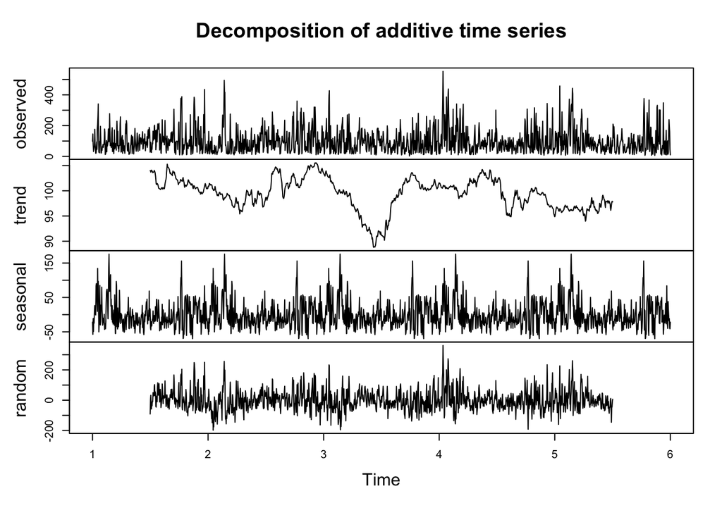

```r
tsfilleddataday<-ts(filleddataday,frequency = 365)
de<-decompose(tsfilleddataday)
plot(de)
```

在这个模型中可以读出的最明显的信息便是2012年初通过的新《环境空气质量标准》使得pm2.5浓度骤然下降，然而在严控了一段时间之后便再次回升。

### 回归

我们考虑数据集中气象数据的信息。先做一个总体拟合。

```r
reg<-lm(pm2.5~cbwd+DEWP+TEMP+PRES+Is+Ir+Iws,data)
summary(reg)
```

```
##
## Call:
## lm(formula = pm2.5 ~ cbwd + DEWP + TEMP + PRES + Is + Ir + Iws,
##     data = data)
##
## Residuals:
##     Min      1Q  Median      3Q     Max
## -180.23  -51.32  -15.80   31.36  885.04
##
## Coefficients:
##               Estimate Std. Error t value Pr(>|t|)
## (Intercept)  1.829e+03  7.196e+01  25.418  < 2e-16 ***
## cbwdNE      -2.674e+01  1.428e+00 -18.722  < 2e-16 ***
## cbwdNW      -3.011e+01  1.173e+00 -25.667  < 2e-16 ***
## cbwdSE       3.882e+00  1.092e+00   3.555 0.000378 ***
## DEWP         4.025e+00  5.324e-02  75.597  < 2e-16 ***
## TEMP        -6.254e+00  6.800e-02 -91.969  < 2e-16 ***
## PRES        -1.616e+00  7.033e-02 -22.972  < 2e-16 ***
## Is          -3.301e+00  5.028e-01  -6.564 5.28e-11 ***
## Ir          -6.230e+00  2.783e-01 -22.387  < 2e-16 ***
## Iws         -2.013e-01  8.752e-03 -23.003  < 2e-16 ***
## ---
## Signif. codes:  0 '***' 0.001 '**' 0.01 '*' 0.05 '.' 0.1 ' ' 1
##
## Residual standard error: 79.16 on 41747 degrees of freedom
##   (2067 observations deleted due to missingness)
## Multiple R-squared:  0.2606, Adjusted R-squared:  0.2604
## F-statistic:  1635 on 9 and 41747 DF,  p-value: < 2.2e-16
```

发现拟合效果尚可，R方为0.26，可以解释一部分信息。所以我们尝试将气象数据中的信息从时间序列数据中剔除。

```r
summary(step(reg))
```

```
## Start:  AIC=365092.2
## pm2.5 ~ cbwd + DEWP + TEMP + PRES + Is + Ir + Iws
##
##        Df Sum of Sq       RSS    AIC
## <none>              261619320 365092
## - Is    1    270052 261889372 365133
## - Ir    1   3140662 264759982 365589
## - PRES  1   3307189 264926510 365615
## - Iws   1   3316060 264935381 365616
## - cbwd  3   8643211 270262531 366443
## - DEWP  1  35814416 297433736 370448
## - TEMP  1  53006449 314625770 372794
```

```
##
## Call:
## lm(formula = pm2.5 ~ cbwd + DEWP + TEMP + PRES + Is + Ir + Iws,
##     data = data)
##
## Residuals:
##     Min      1Q  Median      3Q     Max
## -180.23  -51.32  -15.80   31.36  885.04
##
## Coefficients:
##               Estimate Std. Error t value Pr(>|t|)
## (Intercept)  1.829e+03  7.196e+01  25.418  < 2e-16 ***
## cbwdNE      -2.674e+01  1.428e+00 -18.722  < 2e-16 ***
## cbwdNW      -3.011e+01  1.173e+00 -25.667  < 2e-16 ***
## cbwdSE       3.882e+00  1.092e+00   3.555 0.000378 ***
## DEWP         4.025e+00  5.324e-02  75.597  < 2e-16 ***
## TEMP        -6.254e+00  6.800e-02 -91.969  < 2e-16 ***
## PRES        -1.616e+00  7.033e-02 -22.972  < 2e-16 ***
## Is          -3.301e+00  5.028e-01  -6.564 5.28e-11 ***
## Ir          -6.230e+00  2.783e-01 -22.387  < 2e-16 ***
## Iws         -2.013e-01  8.752e-03 -23.003  < 2e-16 ***
## ---
## Signif. codes:  0 '***' 0.001 '**' 0.01 '*' 0.05 '.' 0.1 ' ' 1
##
## Residual standard error: 79.16 on 41747 degrees of freedom
##   (2067 observations deleted due to missingness)
## Multiple R-squared:  0.2606, Adjusted R-squared:  0.2604
## F-statistic:  1635 on 9 and 41747 DF,  p-value: < 2.2e-16
```

发现并没有删除任何变量。所以我们将pm2.5对气象数据进行多元拟合，从原始数据中减去拟合结果，然后在进行时间序列回归。

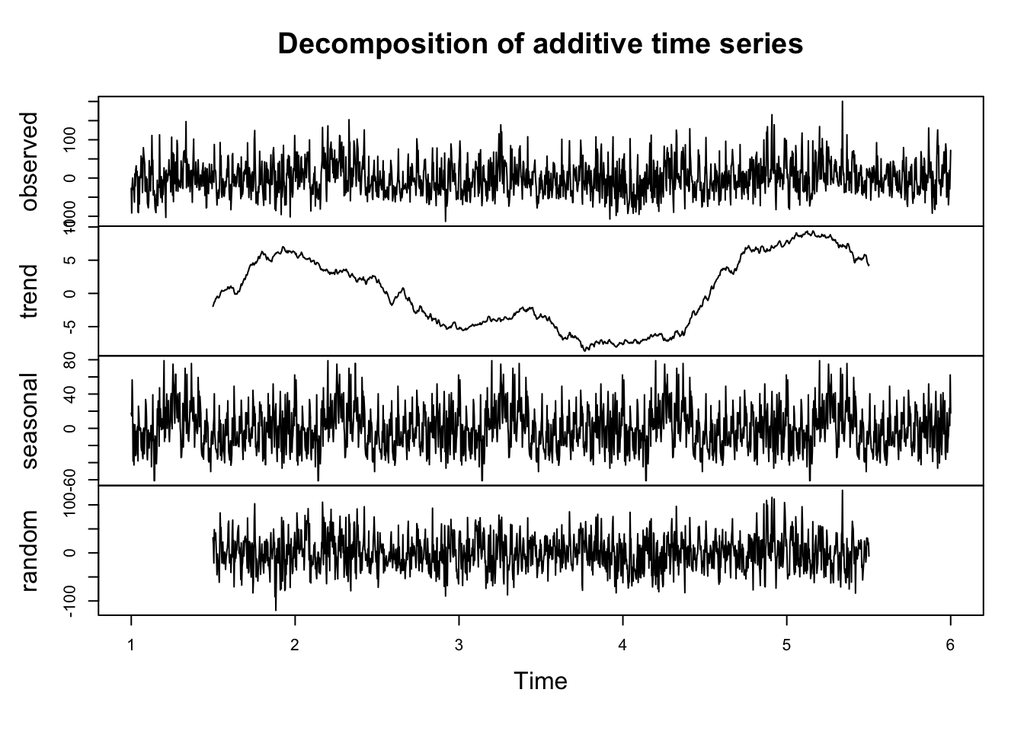

```r
regdata<-predict(data,object = reg)
data2<-data
## 减去气象信息
data2$pm2.5<-filleddataday-regdata
dataday<-getdata("day",data2)
tsfilleddataday<-ts(dataday$pm2.5,frequency = 365)
de<-decompose(tsfilleddataday,type = "add")
plot(de)
```

```r
Box.test(de$random)
```

```
##
##  Box-Pierce test
##
## data:  de$random
## X-squared = 166.09, df = 1, p-value < 2.2e-16
```

从模型解释上来说，对气象数据拟合后再进行成分拆分代表着去除自然因素对pm2.5的影响，只考虑序列自身的相关性和人为因素的影响。而decompose的结果也的确如此：周期性体现出明显的冬季高夏季低，这是冬季供暖的影响；趋势性体现在2012-13年度较低，体现了相关政策的作用。

接下来，我们分别用四种方法（直接进行平稳序列建模，STL建模，回归后平稳建模和回归后STL建模）进行预测，以2010、2011年的数据为例，预测2011年12月的pm2.5的日均值。

```r
test<-function(trainingdata,testdata,method){

  ## 平稳

  if (method=="stationary"){
    # 准备数据
    trainingdata<-getdata("day",trainingdata)
    testdata<-getdata("day",testdata)
    trainingdata$pm2.5<-impute(trainingdata$pm2.5,mean)
    # 拟合模型
    tmodel<-arima(trainingdata$pm2.5,order = c(4,0,4))
    # 预测
    forecast <- forecast(tmodel,h=31, level = c(99.5))
    # 可视化
    plotdata<-data.frame(c(forecast$upper,forecast$lower,forecast$mean,testdata$pm2.5),c(seq(31),seq(31),seq(31),seq(31)),c(rep(1,31),rep(2,31),rep(3,31),rep(4,31)))
    colnames(plotdata)<-c("value","no","group")
    p<-ggplot(plotdata,aes(x=no,y=value,group=group,colour=as.factor(group)))+geom_line()
    print(p)
    print("MSE:")
    print(sum((forecast$mean-testdata$pm2.5)*(forecast$mean-testdata$pm2.5)))
  }

  ## STL

  else if (method=="STL"){
    # 准备数据
    trainingdata<-getdata("day",trainingdata)
    testdata<-getdata("day",testdata)
    trainingdata$pm2.5<-impute(trainingdata$pm2.5,mean)
    tsfilleddataday<-ts(trainingdata$pm2.5,frequency = 30)
    # 拟合模型
    de<-decompose(tsfilleddataday,type = "add")
    # 可视化
    plotdata<-data.frame(c(de$seasonal[1:31]+100,testdata$pm2.5),c(seq(31),seq(31)),c(rep(1,31),rep(2,31)))
    colnames(plotdata)<-c("value","no","group")
    p<-ggplot(plotdata,aes(x=no,y=value,group=group,colour=as.factor(group)))+geom_line()
    print(p)
    print("MSE:")
    print(sum((c(de$seasonal[1:31]+100-testdata$pm2.5)*(de$seasonal[1:31]+100-testdata$pm2.5))))
  }

  ## 气象+平稳

  else if (method=="regstationary"){
    # 回归
    reg<-lm(pm2.5~cbwd+DEWP+TEMP+PRES+Is+Ir+Iws,trainingdata)
    # 准备数据
    trainingdata$pm2.5<-trainingdata$pm2.5-predict(reg,trainingdata)
    trainingdata$pm2.5<-impute(trainingdata$pm2.5,mean)
    trainingdata<-getdata("day",trainingdata)
    # 储存拟合数据
    testdata1<-testdata
    testdata1$pm2.5<-predict(reg,testdata)
    testdata1<-getdata("day",testdata1)
    testdata<-getdata("day",testdata)
    # 拟合
    tmodel<-arima(trainingdata$pm2.5,order = c(4,0,4))
    # 预测
    forecast <- forecast(tmodel,h=31, level = c(99.5))
    # 可视化
    plotdata<-data.frame(c(forecast$upper+testdata1$pm2.5,forecast$lower+testdata1$pm2.5,forecast$mean+testdata1$pm2.5,testdata$pm2.5),c(seq(31),seq(31),seq(31),seq(31)),c(rep(1,31),rep(2,31),rep(3,31),rep(4,31)))
    colnames(plotdata)<-c("value","no","group")
    p<-ggplot(plotdata,aes(x=no,y=value,group=group,colour=as.factor(group)))+geom_line()
    print(p)
    print("MSE:")
    print(sum((forecast$mean+testdata1$pm2.5-testdata$pm2.5)*(forecast$mean+testdata1$pm2.5-testdata$pm2.5)))
  }

  ## 气象+STL

  else if (method=="regSTL"){
    # 回归
    reg<-lm(pm2.5~cbwd+DEWP+TEMP+PRES+Is+Ir+Iws,trainingdata)
    # 准备数据
    trainingdata$pm2.5<-trainingdata$pm2.5-predict(reg,trainingdata)
    trainingdata$pm2.5<-impute(trainingdata$pm2.5,mean)
    trainingdata<-getdata("day",trainingdata)
    # 储存回归结果
    testdata1<-testdata
    testdata1$pm2.5<-predict(reg,testdata)
    testdata1<-getdata("day",testdata1)
    testdata<-getdata("day",testdata)
    tsfilleddataday<-ts(trainingdata$pm2.5,frequency = 30)
    # 预测
    de<-decompose(tsfilleddataday,type = "add")
    plotdata<-data.frame(c(de$seasonal[1:31]+testdata1$pm2.5,testdata$pm2.5),c(seq(31),seq(31)),c(rep(1,31),rep(2,31)))
    colnames(plotdata)<-c("value","no","group")
    # 可视化
    p<-ggplot(plotdata,aes(x=no,y=value,group=group,colour=as.factor(group)))+geom_line()
    print(p)
    print("MSE:")
    print(sum((c(de$seasonal[1:31]+testdata1$pm2.5-testdata$pm2.5)*(de$seasonal[1:31]+testdata1$pm2.5-testdata$pm2.5))))
  }
}
```

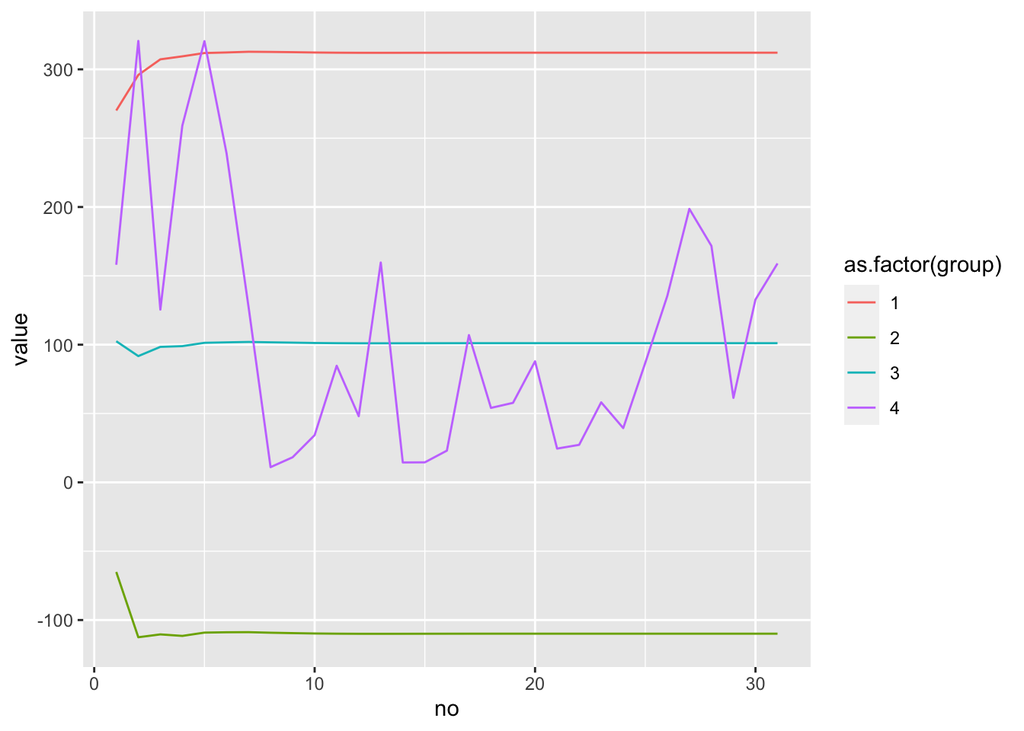

```
## [1] "MSE:"
## [1] 239833.5
```

```r
test(data[1:16776,],data[16777:17520,],"stationary")
```

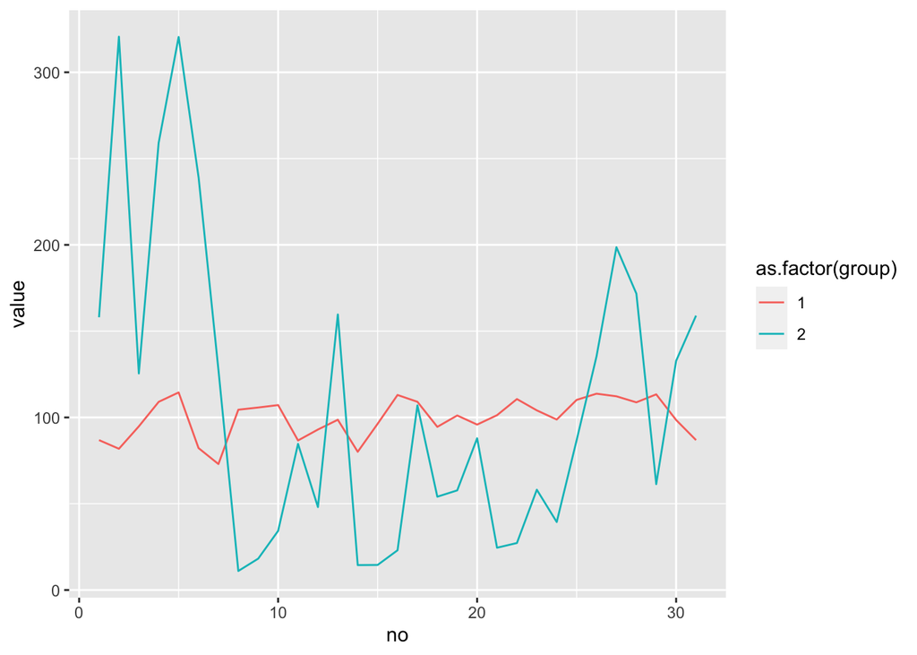

```
## [1] "MSE:"
## [1] 245798.3
```

```r
test(data[1:16776,],data[16777:17520,],"STL")
```

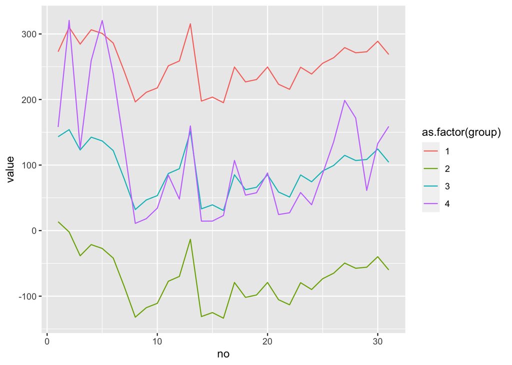

```
## [1] "MSE:"
## [1] 118488.5
```

```r
test(data[1:16776,],data[16777:17520,],"regstationary")
```

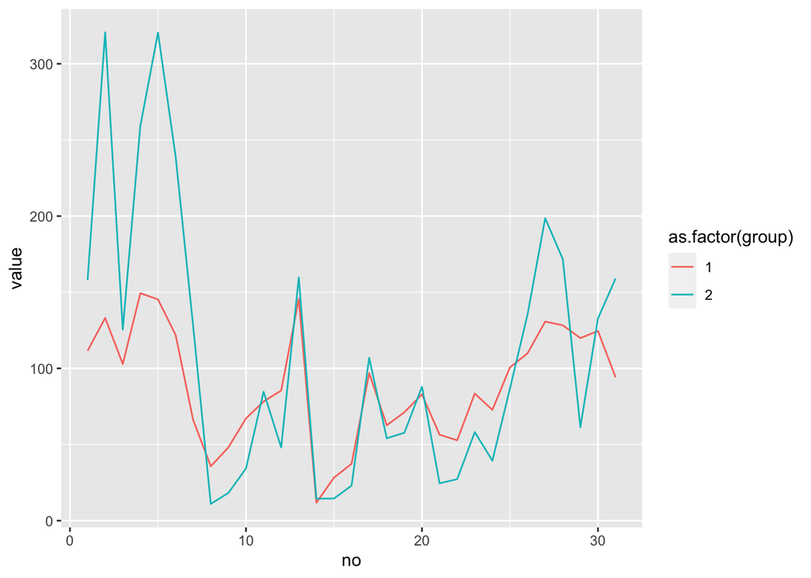

```
## [1] "MSE:"
## [1] 121606.5
```

```r
test(data[1:16776,],data[16777:17520,],"regSTL")
```

针对这四组结果做点评：

- 给出的预测完全基于均值，变动不大，没有太大的意义；置信区间范围很广；MSE值相对较大。得出该模型虽然简单但只适合预测长期趋势，不够精确。
- 预测同样基本基于均值，和平稳时间序列模型相同
- 可以看出预测在向实际值靠拢，证明气象数据里的信息非常又用；图中的置信区间仍然过宽，没有太大意义；MSE是最小的。总体来说，回归-平稳时间序列模型表现最好。
- 和回归-平稳时间序列模型差不多。

注意到加入气象数据信息后表现大幅提升，而采用ARIMA和STL模型则不会产生太大的区别，由此我们也有结论：PM2.5含量预测任务中主要可预测的部分是气象条件和自相关的约束条件，周期和趋势需要额外的领域知识或补充信息。

### 信息解读

- 缺失值往往集中在一两天内
- 气象条件对pm2.5影响很大
- 冬季供暖对pm2.5影响很大
- 2012年新《环境空气质量标准》出台后，环境污染得到有效缓解，但不到一年以后便大幅反弹
- 回归-ARIMA模型能够做出最好的预测

### 政策建议

- 在趋势分解图中我们看到，政策出台的一段时间后往往因为执行变得宽松而效果消失
- 选择周期性把控，在风力强、风向有利（东北、西北风）的时候选择放宽排放标准，为企业减负；在其他时间仍然执行强标准
- 利用回归-ARIMA模型预测pm2.5

### 参考文献

[1] Liang, X., Zou, T., Guo, B., Li, S., Zhang, H., Zhang, S., Huang, H. and Chen, S. X. (2015). Assessing Beijing’s PM2.5 pollution: severity, weather impact, APEC and winter heating. Proceedings of the Royal Society A, 471, 20150257. [2] Cryer, Jonathan D., Chan, Kung-Sik, Time Series Analysis With Applications in R. 2008. Springer-Verlag New York.